# mda_mchester

mchester

05/10/2021

# **Introduction**

### **Purpose**

The purpose of this markdown is to complete STAT 545A Mini-Data Analysis (Milestone 1). Several open-sourced datasets will be explored, and one final dataset will be visualized for research purposes.

### **Author**

The author of this code is Marshall Chester, with open sourced data from the `datateachr` library.

### **Packages**

The following packages must be installed:

```r
install.packages("devtools")
devtools::install_github("UBC-MDS/datateachr")
```

The following libraries must be loaded:

```r
library(datateachr)
library(tidyverse)
```

# **Task 1: Choose dataset**

### **Initial ranking**

1. flow_sample
2. cancer_sample
3. vancouver_trees
4. apt_buildings

### **Dataset exploration**

```r
dim(flow_sample)
```

```
## [1] 218   7
```

```r
class(flow_sample)
```

```
## [1] "tbl_df"     "tbl"        "data.frame"
```

```r
dim(cancer_sample)
```

```
## [1] 569  32
```

```r
class(cancer_sample)
```

```
## [1] "spec_tbl_df" "tbl_df"      "tbl"         "data.frame"
```

```r
dim(vancouver_trees)
```

```
## [1] 146611     20
```

```r
class(vancouver_trees)
```

```
## [1] "tbl_df"     "tbl"        "data.frame"
```

```r
dim(apt_buildings)
```

```
## [1] 3455   37
```

```r
class(apt_buildings)
```

```
## [1] "tbl_df"     "tbl"        "data.frame"
```

### **Dataset attributes**

| Dataset | Rows | Columns | Class | Potential Research Question |
| --- | --- | --- | --- | --- |
| flow_sample | 218 | 7 | data.frame | Is maximum flow always within June and July? |
| cancer_sample | 569 | 32 | data.frame | What is the average area of malignant diagnoses? |
| vancouver_trees | 146,611 | 20 | data.frame | Which Vancouver neighbourhood has the greatest number of tree species? |
| apt_buildings | 3,455 | 37 | data.frame | What percentage of buildings built before 2000 have air conditioning? |

### **Pair down**

After viewing the data, I decided to proceed with cancer_sample and apt_buildings. These datasets are rich and include greater than 30 variables and 500 points for exploration and visualization.

### **Final decision**

I have decided to proceed with the cancer_sample dataset due to personal interest in healthcare. The dataset is robust with a significant number of variables and points for further evaluation. With subsetting, I believe this dataset is well suited for analysis of strength of association and predictive modeling.

# **Task 2: Explore dataset**

In the cancer_sample dataset, area_mean and radius_mean are continuous variables and can be explored by plotting each variable on the x and y axis, respectively. A positive, linear relationship is expected. By grouping data points with diagnosis (dichotomous variable), an interesting relationship could be seen.

### **New tibble**

The cancer_sample includes 32 unique variables. A new tibble can be created to include the variables most interesting to the author. For the purpose of model building, this parsed tibble will help to create an efficient workflow.

```r
tibble(cancer_sample) %>% #make new tibble of interesting variables
  select(diagnosis, radius_mean, perimeter_mean, area_mean, smoothness_mean, symmetry_mean)
```

```
## # A tibble: 569 × 6
##    diagnosis radius_mean perimeter_mean area_mean smoothness_mean symmetry_mean
##    <chr>           <dbl>          <dbl>     <dbl>           <dbl>         <dbl>
##  1 M                18.0          123.      1001           0.118          0.242
##  2 M                20.6          133.      1326           0.0847         0.181
##  3 M                19.7          130       1203           0.110          0.207
##  4 M                11.4           77.6      386.          0.142          0.260
##  5 M                20.3          135.      1297           0.100          0.181
##  6 M                12.4           82.6      477.          0.128          0.209
##  7 M                18.2          120.      1040           0.0946         0.179
##  8 M                13.7           90.2      578.          0.119          0.220
##  9 M                13             87.5      520.          0.127          0.235
## 10 M                12.5           84.0      476.          0.119          0.203
## # … with 559 more rows
```

### **Density plot**

Peaks within a density help to understand where the data are concentrated. In the cancer_sample dataset, the area_mean variable provides continuous data on the average area of diagnoses. A density plot can be created to visualize the concentration of values for both malignant and benign diagnoses. With this visualization, a greater understanding is available.

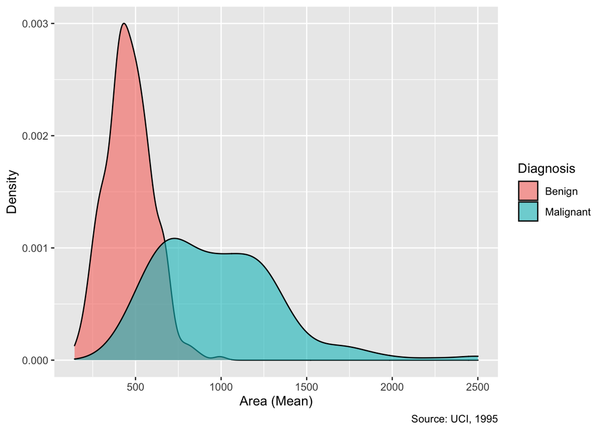

```r
ggplot(cancer_sample, #check density plot of area_mean
       aes(area_mean, fill = diagnosis)) +
  geom_density(alpha = 0.6) +
  labs(x = "Area (Mean)", #add labels
       y = "Density",
       fill = "Diagnosis",
       caption = "Source: UCI, 1995") +
  scale_fill_discrete( #change legend titles
    limits = c("B", "M"),
                      labels = c("Benign", "Malignant"))
```

### **Create boxplot**

A boxplot can provide detailed information between dichotomous and continuous variables. In the cancer_sample dataset, diagnosis is dichotomous (malignant or benign) and symmetry_mean is continuous. A boxplot will help visualize the relationship between malignant and benign diagnoses. There may be an interesting outcome for further consideration.

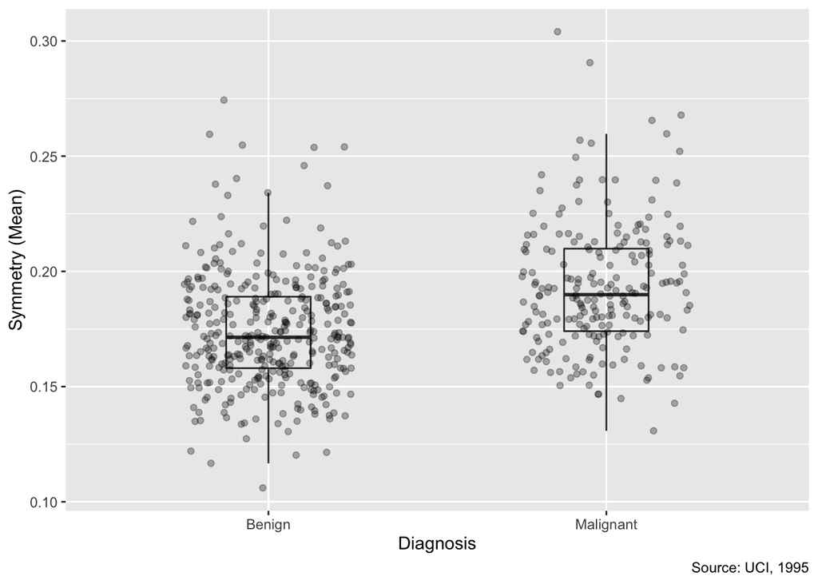

```r
ggplot(cancer_sample, #create boxplot between 2 variables
       aes(x = diagnosis,
           y = symmetry_mean)) +
  geom_boxplot(alpha = 0, #add transparency and change width
               width = 0.25) +
  geom_jitter(alpha = 0.3, #add transparency and change width
              width =0.25) +
  labs(x = "Diagnosis", #add labels
       y = "Symmetry (Mean)",
       caption = "Source: UCI, 1995") +
  scale_x_discrete(breaks = c("B","M"), #change x tick
                   labels = c("Benign", "Malignant"))
```

### **Explore relationship**

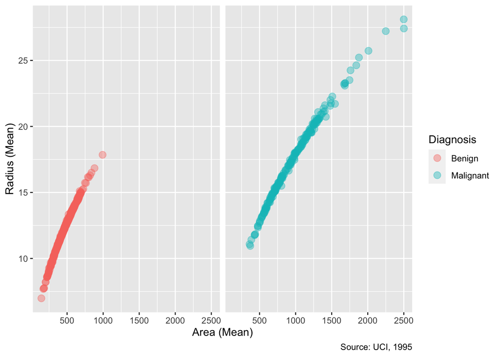

```r
ggplot(cancer_sample, #explore relationship between variables
       aes(x = area_mean,
           y = radius_mean,
           group = diagnosis)) +
  geom_point(aes(color = diagnosis),
             size = 3, #add transparency and change size
             alpha = 0.4) +
    labs(x = "Area (Mean)", #add labels
         y = "Radius (Mean)",
         caption = "Source: UCI, 1995") +
    scale_color_discrete(name = "Diagnosis", #change legend
                         labels=c("Benign", "Malignant")) +
    facet_wrap(~diagnosis) + #facet
  theme(strip.text.x = element_blank())
```

# **Task 3: Research Questions**

With the dataset selected and explored, four potential research questions are postulated.

1. Which subsetted variables are most predictive of a malignant diagnosis?
2. Which subsetted variables are least predictive of a benign diagnosis?
3. Is the relationship between symmetry and diagnoses statistically significant?
4. What is the strength of association between mean radius and area?